# HUDK4051: Prediction - Comparing Trees

Vidya Madhavan

06/04/2021

The aim of this project is to model student data to predict particular decisions using three different tree algorithms - the CART, C4.5 (Conditional Inference Tree) and C5.0. We will be using these algorithms to attempt to predict which students drop out of courses. Many universities have a problem with students over-enrolling in courses at the beginning of semester and then dropping most of them as the make decisions about which classes to attend. This makes it difficult to plan for the semester and allocate resources. However, schools do not want to restrict the choice of their students. One solution is to create predictions of which students are likely to drop out of which courses, and use these predictions to carry out better informed semester planning.

## Software

In order to generate our models we need the following packages: - The [caret](https://cran.r-project.org/web/packages/caret/index.html) package, which brings all the different prediction package algorithms under one hood using the same syntax. - An algorithm from the [Weka suite](https://www.cs.waikato.ac.nz/~ml/weka/). Weka is a collection of machine learning algorithms that have been implemented in Java and made freely available by the University of Waikato in New Zealand. To access these algorithms we will need to first install both the [Java Runtime Environment (JRE) and Java Development Kit](http://www.oracle.com/technetwork/java/javase/downloads/jre9-downloads-3848532.html) on our machine. We then install the [RWeka](https://cran.r-project.org/web/packages/RWeka/index.html) package within R. - The [C50](https://cran.r-project.org/web/packages/C50/index.html) package.

## Data

The data used here comes from a university registrar’s office. The code book for the variables are available in the file code-book.txt.

We begin by uploading the drop-out.csv data into R as a data frame.

```r
library(C50)
library(caret)
library(RWeka)
library(tidyverse)
library(GGally)
library(lubridate)
library(party)
drop_out <- read.csv("drop-out.csv")
```

The next step is to separate our data set into a training set and a test set. We randomly select 25% of the students to be the test data set and leave the remaining 75% for your training data set.

```r
set.seed(1313)
 drop_out <- drop_out %>% mutate(student_id = as.factor(student_id), course_id = as.factor(course_id), gender = as.factor(gender),enroll_date_time = as.POSIXct(enroll_date_time, origin = "2010-01-01", tz = "GMT"),complete = factor(complete, levels = c("no","yes")),international = factor(international, levels = c("no","yes")), online = factor(online, levels = c("no","yes")))
```

```r
perc_75 <- (unique(drop_out$student_id) %>% length) * .75
perc_75 <- perc_75 %>% round
train_ids <- sample(unique(drop_out$student_id))[1:perc_75]
drop_out <- drop_out %>% mutate(type = ifelse(student_id %in% train_ids, "train", "test"))
drop_out_train <- drop_out %>% filter(type == "train")
drop_out_test <- drop_out %>% filter(type == "test")
```

In this project, we intend to predict the parameter of ‘Complete’ which refers to completing a course.

We begin visualizing the relationships between our chosen variables as a scatterplot matrix. Based on this visualizarion, we notice that the categorical variables do not render proper visualizations.

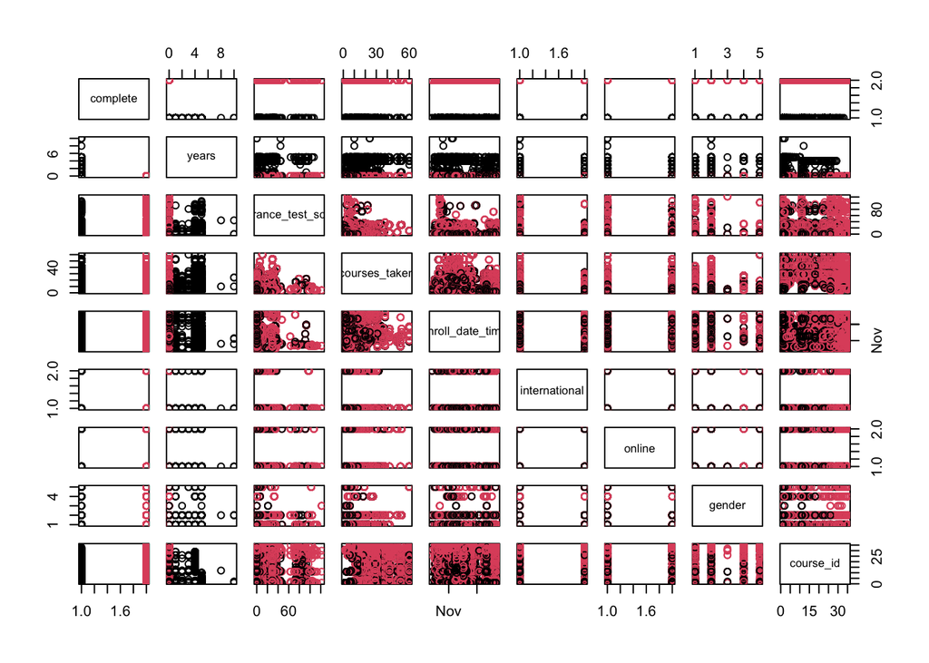

```r
pairs(~complete + years + entrance_test_score+ courses_taken + enroll_date_time + international + online + gender + course_id,data = drop_out, col = factor(drop_out$complete))
```

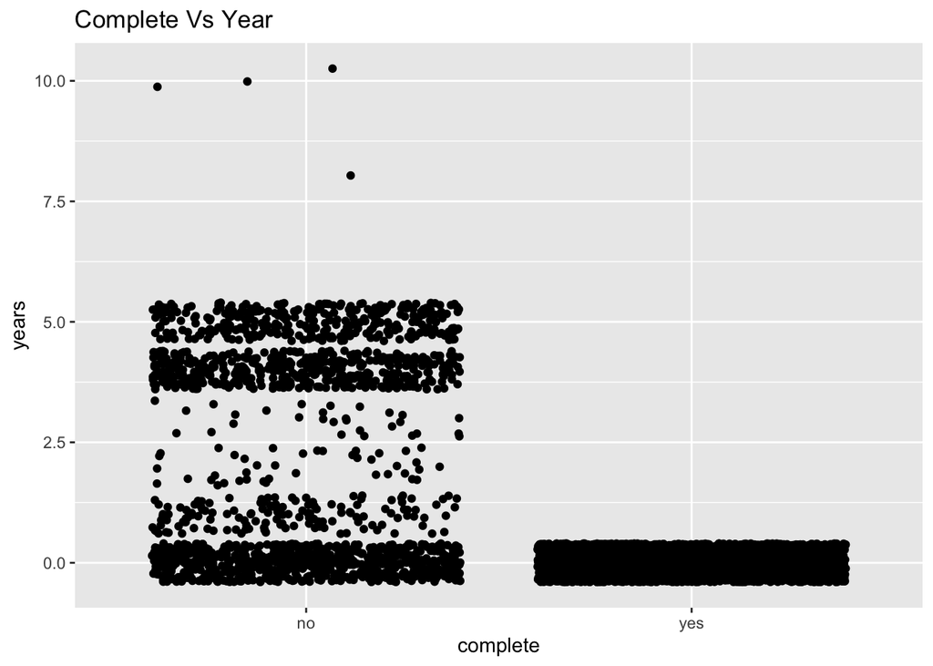

```r
ggplot(drop_out,
       aes(y = years,
           x = complete)) +
  geom_jitter() +
  labs(title = "Complete Vs Year")
```

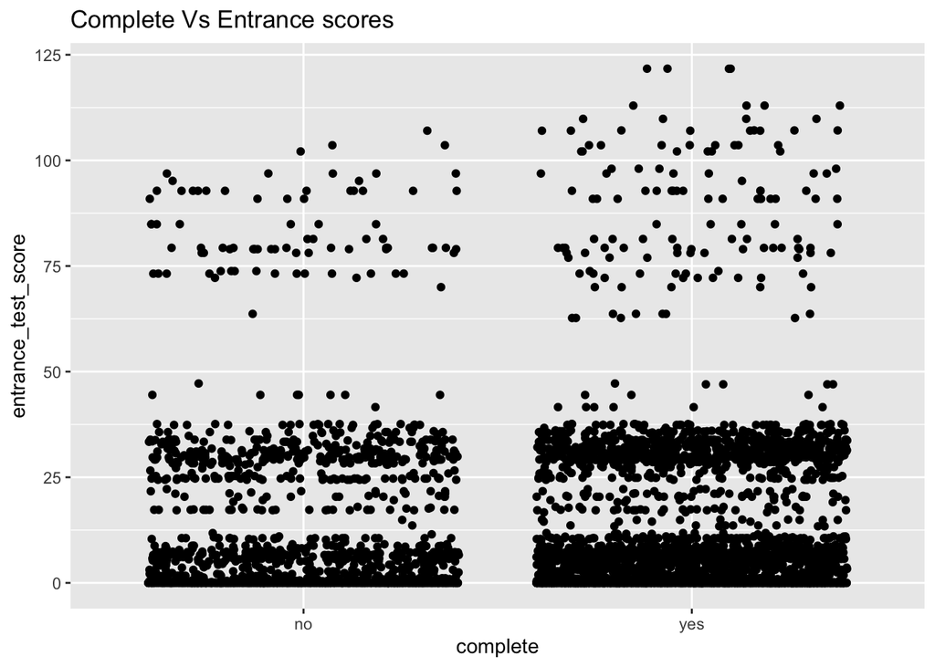

```r
ggplot(drop_out,
       aes(y = entrance_test_score,
           x = complete)) +
  geom_jitter() +
  labs(title = "Complete Vs Entrance scores")
```

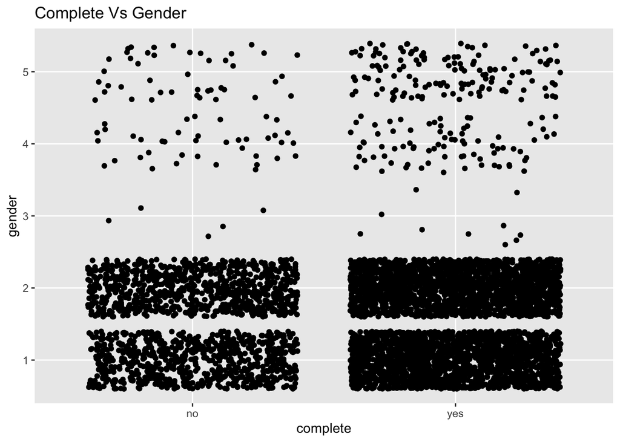

```r
ggplot(drop_out,
       aes(y = gender,
           x = complete)) +
  geom_jitter() +
  labs(title = "Complete Vs Gender")
```

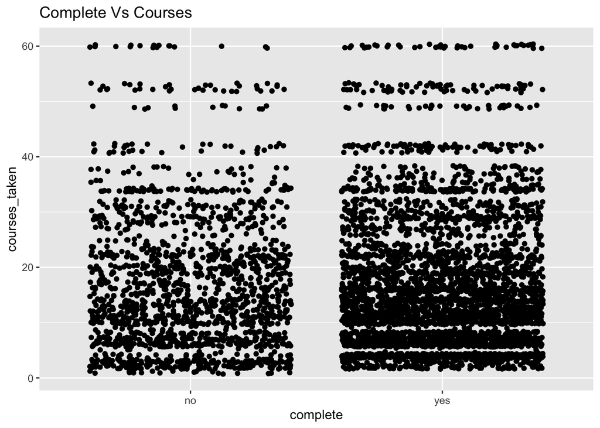

```r
ggplot(drop_out,
       aes(y = courses_taken,
           x = complete)) +
  geom_jitter() +
  labs(title = "Complete Vs Courses")
```

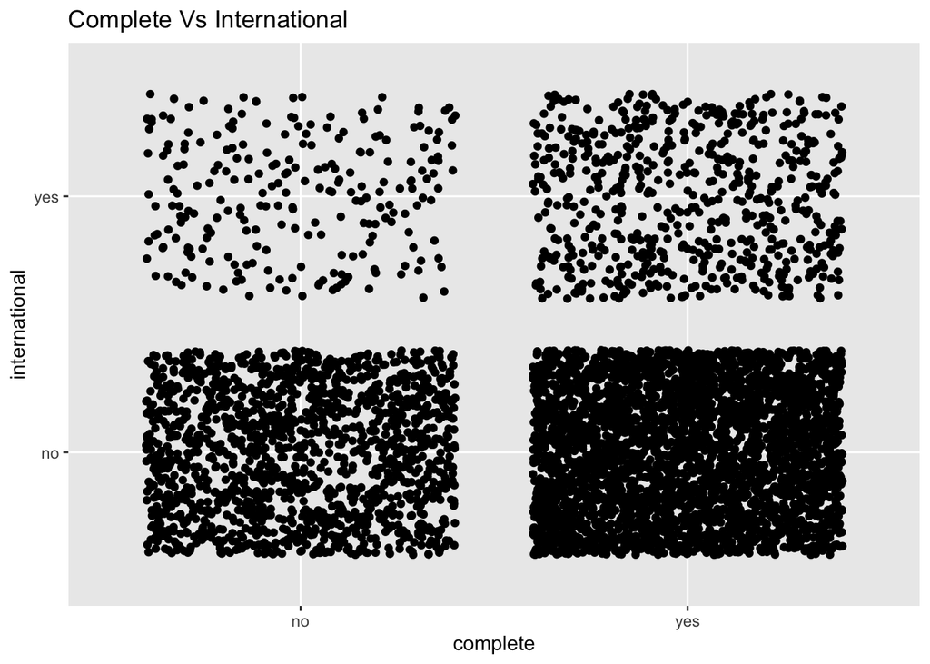

```r
ggplot(drop_out,
       aes(y = international,
           x = complete)) +
  geom_jitter() +
  labs(title = "Complete Vs International")
```

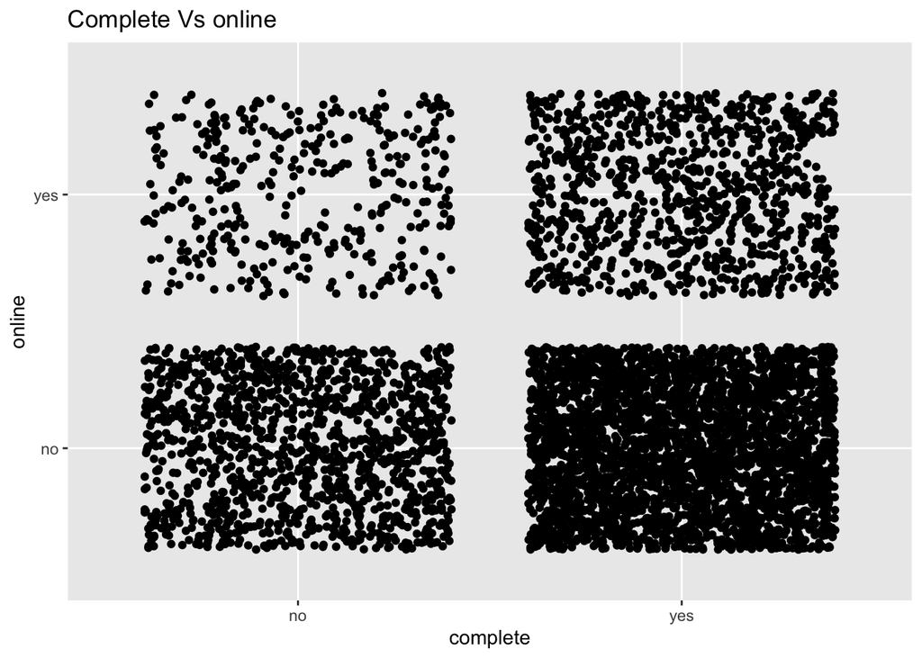

```r
ggplot(drop_out,
       aes(y = online,
           x = complete)) +
  geom_jitter() +
  labs(title = "Complete Vs online")
```

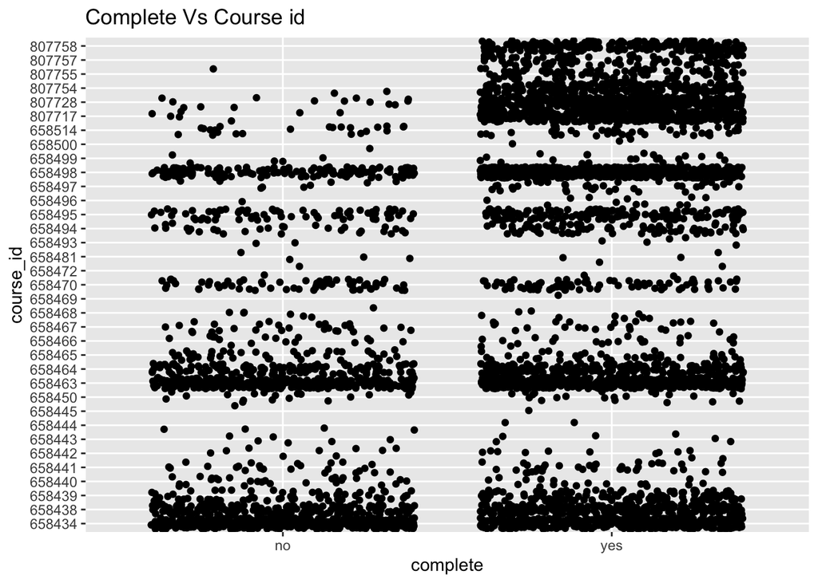

```r
ggplot(drop_out,
       aes(y = course_id,
           x = complete)) +
  geom_jitter() +
  labs(title = "Complete Vs Course id")
```

In order to approximately visualize our categorical variables, we introduce jitter onto the scatterplots.

```r
pdf(file = "/Users/vidyamadhavan/Desktop/HUDK\ 4050/HUDK\ 4051\ SQL\ +\ Pred/prediction/SCP_matrix.pdf",
    # The directory you want to save the file in
     width = 10, # The width of the plot in inches
     height = 10) # The height of the plot in inches

ggpairs(drop_out %>% select(-type,-student_id,-course_id), progress = F,upper =list(continuous = wrap("cor", size=5),lower = list(continuous = wrap("points", position = position_jitter(height = 3, width = 3)))))
dev.off()
```

From the individual scatterplots that I generated, I tried to make meaningful inferences pertaining to course completion in relation with other variables in the dataset. Since our variable of interest is categorical, I used jitter in order to overcome overpopulation. From the graphs, we can see the following: 1. All the students who have completed are have been enrolled in the course for ‘0’ years. 2. There seems to be very few dropouts from the the courses with IDs beginning with 8. This could be due to naturally low enrolment as well.

## CART Trees

We now construct a classification tree that predicts the ‘complete’ variable using the caret package.

```r
library(caret)
TRAIN1 <- drop_out_train %>% select(-type)
TRAIN2 <- TRAIN1[,c(2:10)] #Remove the student_id variable that we do not want to use in the model

#caret does not summarize the metrics we want by default so we have to modify the output
MySummary  <- function(data, lev = NULL, model = NULL){
  df <- defaultSummary(data, lev, model)
  tc <- twoClassSummary(data, lev, model)
  pr <- prSummary(data, lev, model)
  out <- c(df,tc,pr)
  out}

#Define the control elements we would like to use
ctrl <- trainControl(method = "repeatedcv", #Tell caret to perform k-fold cross validation
                repeats = 3, #Tell caret to repeat each fold three times
                classProbs = TRUE, #Calculate class probabilities
                summaryFunction = MySummary)

#Define the model
#install.packages('e1071', dependencies=TRUE)
#install.packages('MLmetrics', dependencies=TRUE)

cartFit <- train(complete ~ ., #Define which variable to predict
                data = TRAIN2, #Define the data set to train the model on
                trControl = ctrl, #Tell caret the control elements
                method = "rpart", #Define the model type
                metric = "Accuracy", #Final model choice is made according to sensitivity
                preProc = c("center", "scale")) #Center and scale the data to minimize the
#Check the results
cartFit$finalModel
```

```
## n= 4336
##
## node), split, n, loss, yval, (yprob)
##       * denotes terminal node
##
##  1) root 4336 1280 yes (0.2952030 0.7047970)
##    2) years>=-0.1116732 768    0 no (1.0000000 0.0000000) *
##    3) years< -0.1116732 3568  512 yes (0.1434978 0.8565022)
##      6) courses_taken< -1.072772 242  110 yes (0.4545455 0.5454545)
##       12) course_id807717< 1.550507 178   74 no (0.5842697 0.4157303)
##         24) course_id807728< 1.620356 104   12 no (0.8846154 0.1153846) *
##         25) course_id807728>=1.620356 74   12 yes (0.1621622 0.8378378) *
##       13) course_id807717>=1.550507 64    6 yes (0.0937500 0.9062500) *
##      7) courses_taken>=-1.072772 3326  402 yes (0.1208659 0.8791341) *
```

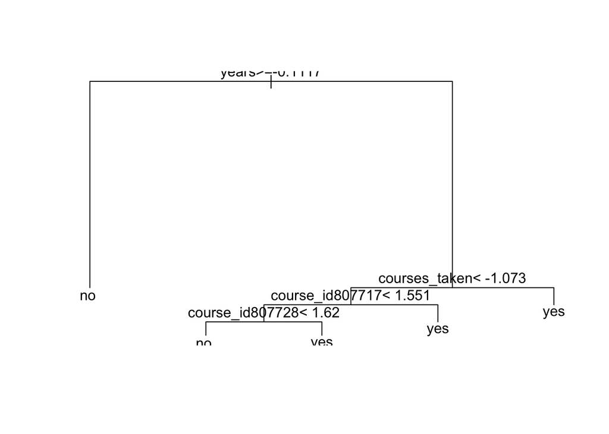

```r
plot(cartFit$finalModel)
text(cartFit$finalModel)
```

```r
cartFit
```

```
## CART
##
## 4336 samples
##    8 predictor
##    2 classes: 'no', 'yes'
##
## Pre-processing: centered (44), scaled (44)
## Resampling: Cross-Validated (10 fold, repeated 3 times)
## Summary of sample sizes: 3902, 3903, 3903, 3902, 3902, 3903, ...
## Resampling results across tuning parameters:
##
##   cp          Accuracy   Kappa      ROC        Sens       Spec       AUC
##   0.00937500  0.9021363  0.7408265  0.8420094  0.6778646  0.9960727  0.2741508
##   0.02083333  0.8879957  0.6976378  0.8130721  0.6257812  0.9978164  0.2629709
##   0.60000000  0.7882700  0.3235605  0.6414062  0.2828125  1.0000000  0.1406466
##   Precision  Recall     F
##   0.9863277  0.6778646  0.8027815
##   0.9922685  0.6257812  0.7659853
##   1.0000000  0.2828125  0.7221752
##
## Accuracy was used to select the optimal model using the largest value.
## The final value used for the model was cp = 0.009375.
```

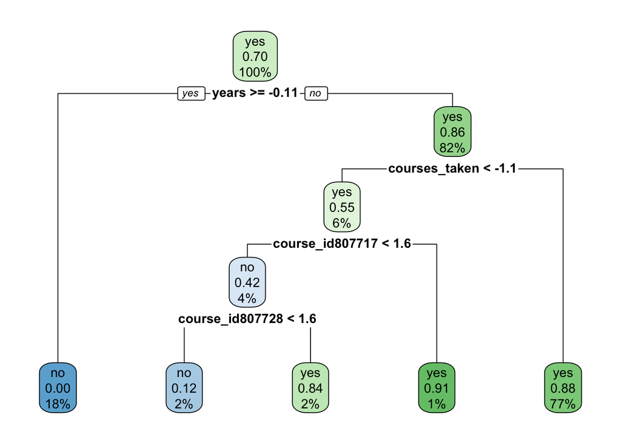

```r
#install.packages(rpart.plot)
library(rpart.plot)
rpart.plot(cartFit$finalModel)
```

```r
print(cartFit)
```

```
## CART
##
## 4336 samples
##    8 predictor
##    2 classes: 'no', 'yes'
##
## Pre-processing: centered (44), scaled (44)
## Resampling: Cross-Validated (10 fold, repeated 3 times)
## Summary of sample sizes: 3902, 3903, 3903, 3902, 3902, 3903, ...
## Resampling results across tuning parameters:
##
##   cp          Accuracy   Kappa      ROC        Sens       Spec       AUC
##   0.00937500  0.9021363  0.7408265  0.8420094  0.6778646  0.9960727  0.2741508
##   0.02083333  0.8879957  0.6976378  0.8130721  0.6257812  0.9978164  0.2629709
##   0.60000000  0.7882700  0.3235605  0.6414062  0.2828125  1.0000000  0.1406466
##   Precision  Recall     F
##   0.9863277  0.6778646  0.8027815
##   0.9922685  0.6257812  0.7659853
##   1.0000000  0.2828125  0.7221752
##
## Accuracy was used to select the optimal model using the largest value.
## The final value used for the model was cp = 0.009375.
```

Attributes of the tree and my thoughts on the model:

I feel this is not the best model to use for student performance as it is more efficient for continuous data and the variable we are trying to predict is categorical. Additionally, accuracy may not be the best metric to run the model with as there is varying weightage given to false positives and false negatives in this dataset. based on that sensitivity and specificity would make more sense.

We can use the sensitivity/ specificity metrics to calculate the F1 metric with the formula: F1 = 2* (precision * recall)/(precision +recall) where recall is the same as sensitivity; precision is calculated by True Positives/ (True positives + False Positives) Note that F1 score is the harmonic mean of precision and recall values.

Predicting results from the test data:

```r
library(caret)
TEST2 <- drop_out_test[,c(2:10)] #Remove the student_id variable that we do not want to use in the model

#Generate prediction using previously trained model
cartClasses <- predict(cartFit,TEST2)

#Generate model statistics
confusionMatrix(data = cartClasses, as.factor(TEST2$complete))
```

```
## Confusion Matrix and Statistics
##
##           Reference
## Prediction   no  yes
##        no   266    5
##        yes  178 1076
##
##                Accuracy : 0.88
##                  95% CI : (0.8626, 0.8959)
##     No Information Rate : 0.7089
##     P-Value [Acc > NIR] : < 2.2e-16
##
##                   Kappa : 0.6716
##
##  Mcnemar's Test P-Value : < 2.2e-16
##
##             Sensitivity : 0.5991
##             Specificity : 0.9954
##          Pos Pred Value : 0.9815
##          Neg Pred Value : 0.8581
##              Prevalence : 0.2911
##          Detection Rate : 0.1744
##    Detection Prevalence : 0.1777
##       Balanced Accuracy : 0.7972
##
##        'Positive' Class : no
##
```

```r
library(party)
```

Train a Conditional Inference Tree using the `party` package on the same training data and examine your results.

[figure not shown]

```r
TRAIN3 <- TRAIN2 %>% select(-enroll_date_time)
condFit <- ctree(complete~., TRAIN3)
plot(condFit, tp_args = list(beside = TRUE))
```

```r
condFit
```

```
##
##   Conditional inference tree with 9 terminal nodes
##
## Response:  complete
## Inputs:  years, entrance_test_score, courses_taken, course_id, international, online, gender
## Number of observations:  4336
##
## 1) years <= 0; criterion = 1, statistic = 1919.962
##   2) course_id == {658434, 658438, 658439, 658440, 658441, 658443, 658444, 658445, 658463, 658464, 658465, 658466, 658467, 658468, 658470, 658494, 658495}; criterion = 1, statistic = 335.751
##     3) courses_taken <= 3; criterion = 1, statistic = 34.809
##       4) courses_taken <= 2; criterion = 0.995, statistic = 11.516
##         5)*  weights = 48
##       4) courses_taken > 2
##         6) course_id == {658463}; criterion = 1, statistic = 17.255
##           7)*  weights = 34
##         6) course_id == {658434}
##           8)*  weights = 22
##     3) courses_taken > 3
##       9) entrance_test_score <= 2.25; criterion = 0.986, statistic = 13.234
##         10)*  weights = 893
##       9) entrance_test_score > 2.25
##         11)*  weights = 841
##   2) course_id == {658442, 658450, 658469, 658472, 658481, 658493, 658496, 658497, 658498, 658499, 658500, 658514, 807717, 807728, 807754, 807755, 807757, 807758}
##     12) course_id == {658450, 658498, 658514}; criterion = 1, statistic = 73.655
##       13)*  weights = 512
##     12) course_id == {658442, 658469, 658472, 658481, 658493, 658496, 658497, 658499, 658500, 807717, 807728, 807754, 807755, 807757, 807758}
##       14) courses_taken <= 1; criterion = 1, statistic = 24.131
##         15)*  weights = 17
##       14) courses_taken > 1
##         16)*  weights = 1201
## 1) years > 0
##   17)*  weights = 768
```

Attributes of the tree and thoughts on the model:

This model has attributes like year, courses taken, course ID, enrollment test results etc. The attribute of year seems to be a very clear predictor of student completion of the course. The other attributes seem to be less impactful.

This plot gives us the splits based completion across different attributes in a branched form, to give us an idea of how each of these attributes affects the prediction of student course completion. From these we can see that the attribute of year is most categorical in predicting student completion and the other attributes are less impactful at predicting.

Testing the new Conditional Inference model by predicting the test data and generating model fit statistics.

```r
TEST3 <- TEST2 %>% select(-enroll_date_time)
condClasses <- predict(condFit, newdata = TEST3)

 #Generate model statistics
 confusionMatrix(data = condClasses, as.factor(TEST3$complete))
```

```
## Confusion Matrix and Statistics
##
##           Reference
## Prediction   no  yes
##        no   267    5
##        yes  177 1076
##
##                Accuracy : 0.8807
##                  95% CI : (0.8633, 0.8965)
##     No Information Rate : 0.7089
##     P-Value [Acc > NIR] : < 2.2e-16
##
##                   Kappa : 0.6736
##
##  Mcnemar's Test P-Value : < 2.2e-16
##
##             Sensitivity : 0.6014
##             Specificity : 0.9954
##          Pos Pred Value : 0.9816
##          Neg Pred Value : 0.8587
##              Prevalence : 0.2911
##          Detection Rate : 0.1751
##    Detection Prevalence : 0.1784
##       Balanced Accuracy : 0.7984
##
##        'Positive' Class : no
##
```

C4.5 Vs the C5.0 models: 1) The C5.0 algorithm has higher accuracy 2) C5.0 is faster, creating trees more quickly by orders of magnitude 3) The memory required for C5.0 is about 10 times less than that of C4.5 4) Continuous data types 5) Sampling and cross-validation are easier to integrate

Source: Source: https://rulequest.com/see5-comparison.html

Training and testing our data using the C5.0 model:

```r
library(C50)
```

```r
c50Fit <- C5.0(TRAIN2[,-4] %>% mutate(enroll_date_time = as.numeric(enroll_date_time)), TRAIN2[,4])
#Posix date format must be converted back to numeric for C5.0
c50Fit %>% summary
```

```
##
## Call:
## C5.0.default(x = TRAIN2[, -4] %>% mutate(enroll_date_time
##  = as.numeric(enroll_date_time)), y = TRAIN2[, 4])
##
##
## C5.0 [Release 2.07 GPL Edition]      Tue Jun 15 21:48:52 2021
## -------------------------------
##
## Class specified by attribute `outcome'
##
## Read 4336 cases (9 attributes) from undefined.data
##
## Decision tree:
##
## years > 0: no (768)
## years <= 0:
## :...courses_taken > 3: yes (3326/402)
##     courses_taken <= 3:
##     :...course_id in {658438,658439,658440,658441,658442,658443,658444,658445,
##         :             658450,658464,658465,658466,658467,658468,658469,658470,
##         :             658472,658481,658493,658494,658495,658496,658497,658498,
##         :             658499,658500,658514,807754,807755,807757,
##         :             807758}: yes (0)
##         course_id in {658434,658463}: no (104/12)
##         course_id in {807717,807728}:
##         :...courses_taken <= 1: no (17)
##             courses_taken > 1: yes (121/1)
##
##
## Evaluation on training data (4336 cases):
##
##      Decision Tree
##    ----------------
##    Size      Errors
##
##       5  415( 9.6%)   <<
##
##
##     (a)   (b)    <-classified as
##    ----  ----
##     877   403    (a): class no
##      12  3044    (b): class yes
##
##
##  Attribute usage:
##
##  100.00% years
##   82.29% courses_taken
##    5.58% course_id
##
##
## Time: 0.0 secs
```

```r
CClasses <- predict(c50Fit, newdata = TEST2 %>% mutate(enroll_date_time = as.numeric(enroll_date_time)))
confusionMatrix(data = CClasses, as.factor(TEST2$complete))
```

```
## Confusion Matrix and Statistics
##
##           Reference
## Prediction   no  yes
##        no   267    5
##        yes  177 1076
##
##                Accuracy : 0.8807
##                  95% CI : (0.8633, 0.8965)
##     No Information Rate : 0.7089
##     P-Value [Acc > NIR] : < 2.2e-16
##
##                   Kappa : 0.6736
##
##  Mcnemar's Test P-Value : < 2.2e-16
##
##             Sensitivity : 0.6014
##             Specificity : 0.9954
##          Pos Pred Value : 0.9816
##          Neg Pred Value : 0.8587
##              Prevalence : 0.2911
##          Detection Rate : 0.1751
##    Detection Prevalence : 0.1784
##       Balanced Accuracy : 0.7984
##
##        'Positive' Class : no
##
```

## Comparing our three models

caret allows us to compare all three models at once.

```r
condFit <- train(complete ~ ., #Define which variable to predict
                 data = TRAIN2, #Define the data set to train the model on
                 trControl = ctrl, #Tell caret the control elements
                 method = "ctree", #Define the model type
                 metric = "Accuracy", #Final model choice is made according to sensitivity
                 preProc = c("center", "scale"))

c50Fit <- train(complete ~ ., #Define which variable to predict
                 data = TRAIN2, #Define the data set to train the model on
                 trControl = ctrl, #Tell caret the control elements
                 method = "C5.0", #Define the model type
                 metric = "Accuracy", #Final model choice is made according to sensitivity
                 preProc = c("center", "scale")) #Center and scale the data to minimize
```

```r
resamps <-resamples(list(cart = cartFit, condinf = condFit, cfiveo = c50Fit))
summary(resamps)
```

```
##
## Call:
## summary.resamples(object = resamps)
##
## Models: cart, condinf, cfiveo
## Number of resamples: 30
##
## Accuracy
##              Min.   1st Qu.    Median      Mean   3rd Qu.      Max. NA's
## cart    0.8706697 0.8960739 0.9009217 0.9021363 0.9122402 0.9262673    0
## condinf 0.8845266 0.8945254 0.9030023 0.9019842 0.9101382 0.9239631    0
## cfiveo  0.8709677 0.8951028 0.9054209 0.9042894 0.9139723 0.9262673    0
##
## AUC
##              Min.   1st Qu.    Median      Mean   3rd Qu.      Max. NA's
## cart    0.2187691 0.2515811 0.2753651 0.2741508 0.2897208 0.3314473    0
## condinf 0.1810455 0.2005738 0.2278463 0.2252115 0.2410904 0.2865930    0
## cfiveo  0.1605777 0.1820997 0.2006305 0.2017197 0.2215051 0.2601284    0
##
## F
##              Min.   1st Qu.    Median      Mean   3rd Qu.      Max. NA's
## cart    0.7281553 0.7867299 0.7990610 0.8027815 0.8256881 0.8584071    0
## condinf 0.7572816 0.7859681 0.8046469 0.8021518 0.8227162 0.8533333    0
## cfiveo  0.7281553 0.7858623 0.8093023 0.8080062 0.8316564 0.8571429    0
##
## Kappa
##              Min.   1st Qu.    Median      Mean   3rd Qu.      Max. NA's
## cart    0.6497472 0.7220994 0.7366340 0.7408265 0.7695318 0.8095919    0
## condinf 0.6872743 0.7195699 0.7433098 0.7401848 0.7646770 0.8033179    0
## cfiveo  0.6499798 0.7202568 0.7495143 0.7471522 0.7754930 0.8088106    0
##
## Precision
##              Min.   1st Qu.    Median      Mean 3rd Qu. Max. NA's
## cart    0.9545455 0.9790196 0.9890110 0.9863277       1    1    0
## condinf 0.9687500 0.9807845 0.9888834 0.9895734       1    1    0
## cfiveo  0.9591837 0.9780142 0.9887640 0.9865112       1    1    0
##
## Recall
##              Min.   1st Qu.    Median      Mean   3rd Qu.      Max. NA's
## cart    0.5781250 0.6503906 0.6757812 0.6778646 0.7089844 0.7578125    0
## condinf 0.6093750 0.6562500 0.6757812 0.6752604 0.7011719 0.7500000    0
## cfiveo  0.5859375 0.6523438 0.6875000 0.6851563 0.7187500 0.7500000    0
##
## ROC
##              Min.   1st Qu.    Median      Mean   3rd Qu.      Max. NA's
## cart    0.7940538 0.8281228 0.8408466 0.8420094 0.8576068 0.8827741    0
## condinf 0.8620175 0.8940717 0.9022225 0.9018744 0.9103042 0.9299045    0
## cfiveo  0.7880668 0.8245379 0.8412963 0.8406134 0.8585553 0.8750000    0
##
## Sens
##              Min.   1st Qu.    Median      Mean   3rd Qu.      Max. NA's
## cart    0.5781250 0.6503906 0.6757812 0.6778646 0.7089844 0.7578125    0
## condinf 0.6093750 0.6562500 0.6757812 0.6752604 0.7011719 0.7500000    0
## cfiveo  0.5859375 0.6523438 0.6875000 0.6851563 0.7187500 0.7500000    0
##
## Spec
##              Min.   1st Qu.   Median      Mean 3rd Qu. Max. NA's
## cart    0.9868852 0.9942784 0.996732 0.9960727       1    1    0
## condinf 0.9901639 0.9942784 0.996732 0.9969456       1    1    0
## cfiveo  0.9868852 0.9934641 0.996732 0.9960706       1    1    0
```

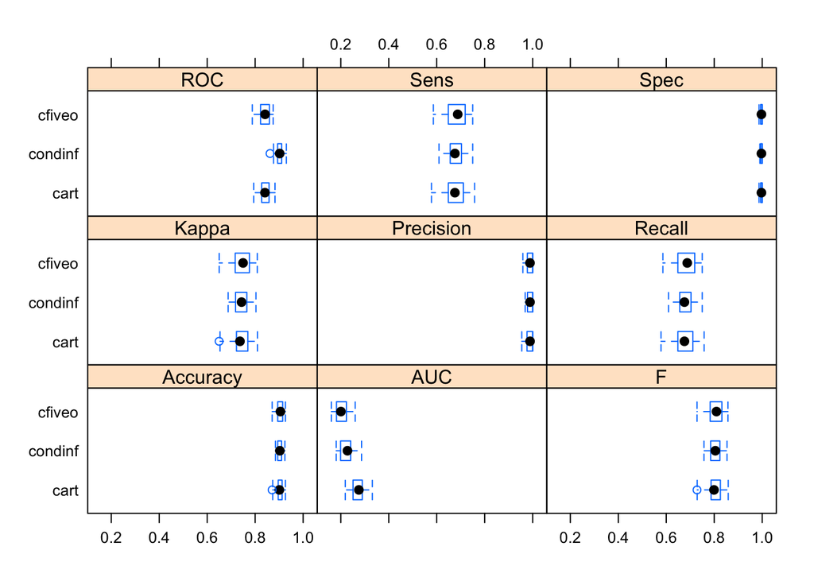

```r
bwplot(resamps)
```

Model summary inferences:

The summary gives the distributions of the accuracy, ROC, sensitivity, specificity, and other model metrics for each of the three models with 30 re-samplings.

```r
getwd()
```

```
## [1] "/Users/vidyamadhavan/Desktop/HUDK 4050/HUDK 4051 SQL + Pred/Vidya Pred/prediction"
```

End